# Data analysis of Traffic Shaping in the world detected by Shaperprobe

Net neutrality exclude every discrimination by the network of content depending on source, destination ou type of transmitted data. According to [Wikipedia](https://en.wikipedia.org/wiki/Network_neutrality), “Net neutrality is the principle that Internet service providers and governments should treat all data on the Internet equally, not discriminating or charging differentially by user, content, site, platform, application, type of attached equipment, and modes of communication”.

- test en up et en down
- explication détection de traffic shapping en up et en down
- « burstsize » (nombre d’octets avant la baisse de vitesse)
- vitesse après bridage (si traffic shaping)
- vitesse moyenne (si pas de traffic shaping)
- capacité de la connexion (up et down)

Learn more about traffic shaping on [Wikipedia](https://en.wikipedia.org/wiki/Traffic_shaping).

Shaperprobe is a free software (under GPL licence) which everyone can execute at home to test the presence and characteristics of traffic shaping on its own internet connection. Data of every test are stored on the MeasurementLab plateforme and are publically accessible under the CC-0 licence (public domain). Note that your IP adress is stored, but it is the only non-anonymous information (and it allow us to find localizations and ISP). Shaperprobe is multi-platform (Windows/Linux/MacOSX/FreeBSD).

**Execute Shaperprobe at home** to test traffic shaping on your own internet connection and improve results below (automatically updated once a week) : [Shaperprobe on the Measurement Lab](http://www.measurementlab.net/tools/shaperprobe)

Shaperprobe's test procedure works like this :

1. connection with the closest available MLab's server
2. estimation of the upload and download speed
3. sending and receiving packets of fixed size for about 2.5 minutes (we have time series of trains speed)
4. detection (or not) of a significative and lasting fall (ie. traffic shaping)

The image below came from the paper wrote by Shaperprobe developers to illustrate a typical example of traffic shaping (you can look at the [pdf here](http://netinfer.com/shaperprobe-imc11.pdf) to understand how Shaperprobe works exactly).

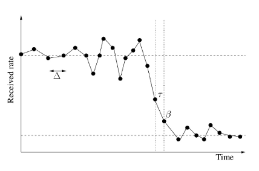

For more information on Shaperprobe, please visit [Netinfer](http://netinfer.com).

## Data presentation

This page is automatically generated once a week, with new data. The code used to download, parse, treat data, and generate this page is available on [Framartin account on github](https://github.com/Framartin/MeasureNetNeutrality/tree/master/MLab/ShaperProbe) under the GPL licence. Feel free to contact me for any suggestion or if you want to get involve.

In this page, **dates of tests expand from 05 mai 2009 to 05 mai 2014**. We have a **total number of tests of 893899** done by 595353 different IP adresses.

Below are drawn histograms of numbers of tests by days and weeks.

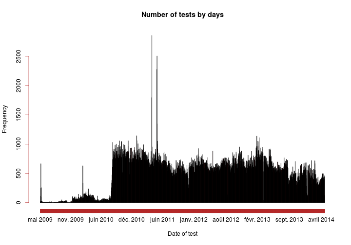

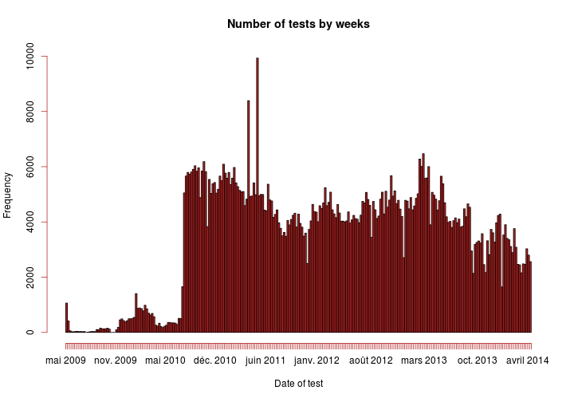

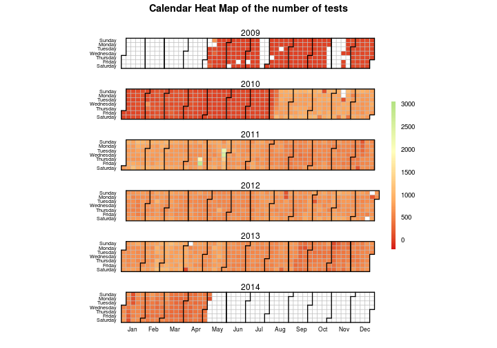

Tests where executed from **166 different countries**. We have data for **1226 distinct ISP**, collected by 53 servers.

Data was qualified into 4 categories (not qualified (by default)/good (IP which have done at least 3 tests)/subject to doubt/false (or absurd)) according to criteria justified by a technical considerations and a statistical exploratory analysis. In the following, we don't use doubtful and absurd data.

## Quick overview of global results

Keep in mind that these results are computed for all tests. As we have different numbers of tests by countries, numbers below are not necessarily a good representation of the proportion of Internet connections, in the world, which are subject to traffic shaping.

| in % | Traffic Shaping | in Upload |
| --- | --- | --- |
| **Traffic Shaping in Download** | FALSE | TRUE |
| FALSE | 67.84 | 8.56 |
| TRUE | 12.71 | 10.89 |

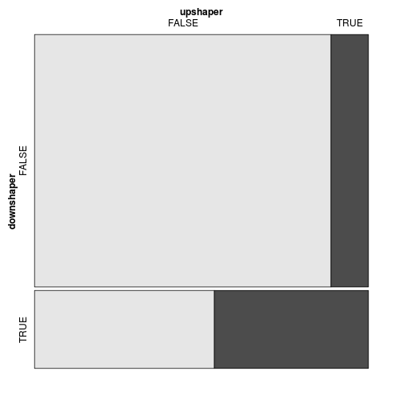

## Traffic Shaping by country

### World Map

World map of the rate of traffic shaping detected in upload or in download by country are represented below. Note that we do not draw countries which have less than 100 tests or less than 50 different IP adresses tested.

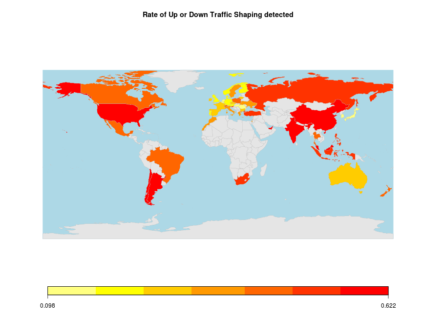

Zoom in Eurasia and in Oceania:

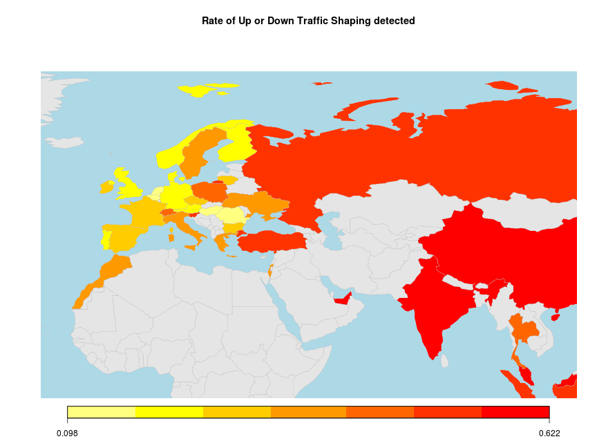

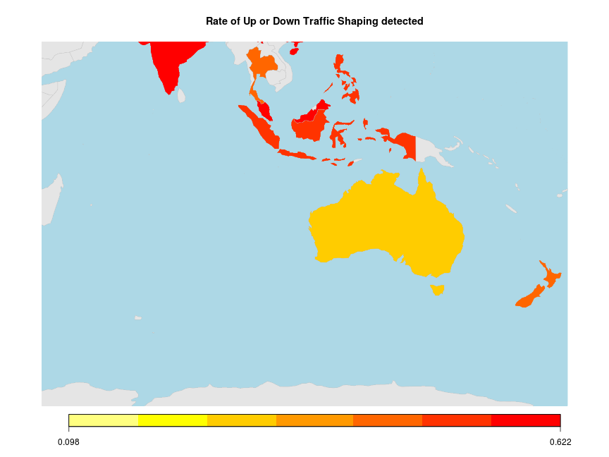

In the maps below, colors represents the estimated rate of connection with traffic shaping (as above), and the size of circles the numbers of tests done in the country.

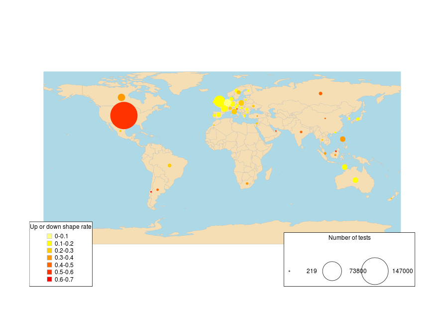

Zoom in Eurasia:

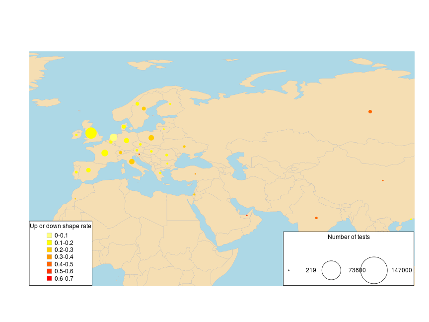

### Numeric results

Below, results agreagated by country are reported.

You should look mainly at the variable “Up or down shape rate”. But be careful to errors : below 15-20 % we don't really know (but high chance there is not a lot of TS in networks). More than 40%, lot of T.S. Moreover to have an idea of the importance of the traffic shaping when it's detected, you can take a look at “Up speed reduction rate” and “Down speed reduction rate”. Moreover, to estimate the reliability of these results, look at the number of distinct IP adresses and the number of tests.

[output not shown]

| Country Code | Country Name | Up shape rate | Down shape rate | Up or down shape rate | Up speed reduction rate | Down speed reduction rate | Number IP | Number tests |
| --- | --- | --- | --- | --- | --- | --- | --- | --- |
| AE | United Arab Emirates | 48.10 | 36.50 | 55.10 | 0.32 | 0.35 | 66 | 234 |
| AR | Argentina | 34.80 | 40.40 | 48.40 | 0.50 | 0.47 | 111 | 869 |
| AT | Austria | 4.70 | 9.80 | 13.50 | 0.42 | 0.41 | 230 | 1061 |
| AU | Australia | 9.80 | 9.70 | 17.80 | 0.27 | 0.45 | 1135 | 5429 |
| BE | Belgium | 5.40 | 7.50 | 11.80 | 0.38 | 0.48 | 355 | 1749 |
| BG | Bulgaria | 7.20 | 11.80 | 16.70 | 0.26 | 0.45 | 82 | 561 |
| BR | Brazil | 16.20 | 17.70 | 28.00 | 0.28 | 0.39 | 484 | 2300 |
| CA | Canada | 9.70 | 24.10 | 31.30 | 0.34 | 0.44 | 1922 | 9854 |
| CH | Switzerland | 17.00 | 8.90 | 24.10 | 0.26 | 0.46 | 318 | 1692 |
| CL | Chile | 45.60 | 27.50 | 62.20 | 0.38 | 0.36 | 52 | 274 |
| CN | China | 34.40 | 28.00 | 47.20 | 0.36 | 0.35 | 53 | 237 |
| CZ | Czech Republic | 9.80 | 10.90 | 16.40 | 0.43 | 0.42 | 161 | 1063 |
| DE | Germany | 8.30 | 7.00 | 14.00 | 0.32 | 0.42 | 1027 | 4650 |
| DK | Denmark | 6.50 | 9.00 | 12.80 | 0.42 | 0.42 | 477 | 2836 |
| ES | Spain | 8.70 | 7.80 | 15.20 | 0.27 | 0.46 | 780 | 3511 |
| FI | Finland | 9.60 | 7.50 | 13.30 | 0.42 | 0.43 | 120 | 564 |
| FR | France | 8.20 | 7.60 | 14.90 | 0.37 | 0.38 | 1733 | 8305 |
| GB | United Kingdom | 5.80 | 8.00 | 12.70 | 0.35 | 0.45 | 3756 | 24605 |
| GR | Greece | 8.60 | 10.90 | 18.60 | 0.30 | 0.38 | 189 | 820 |
| HK | Hong Kong | 6.90 | 6.10 | 11.80 | 0.31 | 0.42 | 84 | 432 |
| HU | Hungary | 4.30 | 7.60 | 10.20 | 0.38 | 0.40 | 228 | 1017 |
| ID | Indonesia | 22.30 | 16.90 | 34.40 | 0.36 | 0.45 | 109 | 492 |
| IE | Ireland | 9.60 | 10.00 | 17.80 | 0.33 | 0.52 | 174 | 806 |
| IL | Israel | 19.80 | 6.10 | 23.00 | 0.29 | 0.52 | 141 | 609 |
| IN | India | 28.40 | 37.90 | 48.40 | 0.38 | 0.39 | 242 | 903 |
| IT | Italy | 12.50 | 10.10 | 20.20 | 0.30 | 0.42 | 1250 | 5155 |
| JP | Japan | 6.40 | 6.40 | 11.30 | 0.40 | 0.46 | 294 | 1651 |
| KR | Korea, Republic of | 7.90 | 4.90 | 11.60 | 0.48 | 0.51 | 95 | 476 |
| LT | Lithuania | 11.20 | 8.80 | 16.80 | 0.44 | 0.44 | 65 | 474 |
| MA | Morocco | 11.80 | 10.80 | 21.80 | 0.34 | 0.47 | 52 | 219 |
| MX | Mexico | 15.30 | 17.70 | 28.60 | 0.32 | 0.43 | 144 | 633 |
| MY | Malaysia | 38.40 | 35.80 | 50.80 | 0.31 | 0.30 | 89 | 374 |
| NL | Netherlands | 4.10 | 6.40 | 9.80 | 0.41 | 0.48 | 1875 | 10094 |
| NO | Norway | 8.10 | 6.90 | 13.60 | 0.41 | 0.46 | 411 | 2268 |
| NZ | New Zealand | 11.20 | 21.20 | 26.20 | 0.27 | 0.45 | 72 | 309 |
| PH | Philippines | 17.30 | 22.50 | 33.50 | 0.37 | 0.41 | 891 | 5117 |
| PL | Poland | 16.60 | 11.20 | 23.50 | 0.32 | 0.42 | 580 | 5333 |
| PT | Portugal | 4.70 | 9.80 | 13.70 | 0.44 | 0.44 | 280 | 1260 |
| RO | Romania | 7.00 | 5.20 | 11.50 | 0.34 | 0.45 | 138 | 1130 |
| RU | Russian Federation | 26.50 | 34.30 | 41.30 | 0.29 | 0.32 | 434 | 1999 |
| SE | Sweden | 16.90 | 7.90 | 21.40 | 0.29 | 0.44 | 517 | 2576 |
| SG | Singapore | 17.40 | 23.30 | 31.90 | 0.39 | 0.43 | 178 | 931 |
| SI | Slovenia | 30.60 | 14.20 | 41.90 | 0.31 | 0.40 | 56 | 331 |
| TH | Thailand | 12.90 | 16.90 | 26.00 | 0.27 | 0.41 | 105 | 418 |
| TR | Turkey | 21.90 | 28.90 | 40.00 | 0.32 | 0.51 | 55 | 221 |
| UA | Ukraine | 10.70 | 16.80 | 22.70 | 0.36 | 0.33 | 106 | 958 |
| US | United States | 35.90 | 44.90 | 54.90 | 0.46 | 0.37 | 22005 | 147330 |
| ZA | South Africa | 10.80 | 25.60 | 33.30 | 0.24 | 0.28 | 215 | 922 |

## Traffic Shaping by ISP

### Numeric results

We describe below the meaning of variables computed for each ISP.

[output not shown]

Below, you can find your country and review results for each ISP which we have data. Keep in mind the number of obervations which must be high to have a significant impact, and that data is not the trust. As explained later, errors are present in these data.

Interpret these results like this :

- if an ISP have an “*Up or down shape rate*” greater than approximately 30%, there is an *high probability* that your ISP is performing traffic shaping on its network
- if an ISP have an “*Up or down shape rate*” lower than approximately 30%, *we cannot say* if an ISP has implementing traffic shaping (it can be the results of errors, or that trafic shaping is implemented in only a part of the ISP's network)

| Country Code | ISP Name | Up shape rate | Down shape rate | Up or down shape rate | Up speed reduction rate | Down speed reduction rate | Number IP | Number tests |
| --- | --- | --- | --- | --- | --- | --- | --- | --- |
| AE | Emirates Integrated Telecommunications Company | 0.30 | 0.17 | 0.35 | 0.30 | 0.38 | 24 | 90 |
| AE | Emirates Telecommunications Corporation (Etisalat) | 0.59 | 0.47 | 0.67 | 0.33 | 0.36 | 42 | 151 |
| AR | Cablevision | 0.70 | 0.72 | 0.77 | 0.62 | 0.51 | 26 | 486 |
| AT | TELE2 | 0.22 | 0.11 | 0.28 | 0.35 | 0.59 | 46 | 196 |
| AU | Adam Internet | 0.04 | 0.05 | 0.09 | 0.30 | 0.70 | 26 | 99 |
| AU | Primus Telecommunications | 0.07 | 0.04 | 0.11 | 0.18 | 0.49 | 21 | 79 |
| AU | TPG Telecom | 0.06 | 0.06 | 0.11 | 0.21 | 0.46 | 206 | 1008 |
| AU | Exetel | 0.07 | 0.04 | 0.12 | 0.20 | 0.37 | 29 | 148 |
| AU | Telstra | 0.10 | 0.08 | 0.17 | 0.27 | 0.47 | 309 | 1237 |
| AU | iiNet | 0.15 | 0.09 | 0.21 | 0.26 | 0.47 | 66 | 266 |
| AU | Dodo Australia | 0.13 | 0.12 | 0.21 | 0.26 | 0.43 | 95 | 695 |
| AU | Microplex | 0.11 | 0.13 | 0.22 | 0.28 | 0.43 | 216 | 938 |
| AU | Internode | 0.16 | 0.14 | 0.25 | 0.33 | 0.38 | 36 | 233 |
| BE | Telenet | 0.03 | 0.06 | 0.09 | 0.40 | 0.45 | 209 | 1140 |
| BE | Voo (brutele) | 0.06 | 0.06 | 0.12 | 0.37 | 0.30 | 55 | 271 |
| BE | Belgacom regional | 0.09 | 0.13 | 0.17 | 0.44 | 0.64 | 61 | 218 |
| BR | Servicos de Comunicao | 0.04 | 0.12 | 0.15 | 0.23 | 0.39 | 217 | 1047 |
| BR | Telemar | 0.12 | 0.10 | 0.20 | 0.29 | 0.33 | 57 | 224 |
| BR | Brasil Telecom | 0.18 | 0.10 | 0.24 | 0.24 | 0.62 | 22 | 90 |
| BR | Global Village Telecom | 0.33 | 0.43 | 0.52 | 0.29 | 0.43 | 42 | 176 |
| BR | Telefônica Brasil | 0.62 | 0.24 | 0.68 | 0.26 | 0.23 | 42 | 188 |
| CA | Videotron Telecom Ltee | 0.03 | 0.04 | 0.06 | 0.38 | 0.62 | 146 | 712 |
| CA | Bell Canada | 0.06 | 0.07 | 0.12 | 0.32 | 0.51 | 187 | 795 |
| CA | Saskatchewan Telecommunications | 0.09 | 0.04 | 0.13 | 0.23 | 0.37 | 31 | 121 |
| CA | Allstream | 0.08 | 0.06 | 0.14 | 0.42 | 0.32 | 32 | 115 |
| CA | Cogeco Cable | 0.06 | 0.12 | 0.15 | 0.21 | 0.42 | 47 | 236 |
| CA | Bell Aliant Regional Communications | 0.11 | 0.06 | 0.15 | 0.40 | 0.36 | 89 | 362 |
| CA | COGECO Cable Canada | 0.11 | 0.07 | 0.17 | 0.33 | 0.60 | 23 | 89 |
| CA | Amanah Tech | 0.07 | 0.20 | 0.25 | 0.45 | 0.36 | 63 | 410 |
| CA | Telus | 0.22 | 0.04 | 0.26 | 0.28 | 0.47 | 235 | 1007 |

[output cut: 157 more lines]

## Characteristics of traffic shaping

meanupburstsize in KB meandownburstsize in KB

```
## [1] 4503
```

```
## [1] 4239
```

```
## [1] 3282
```

```
##       0%      10%      20%      30%      40%      50%      60%      70%
##      1.5     43.0    212.5    797.5   2271.5   4239.0   4820.0   4972.5
##      80%      90%     100%
##   5683.6   9849.5 852421.5
```

```
## [1] 51685
```

```
## [1] 8993
```

```
## [1] 7960
```

```
##      0%     10%     20%     30%     40%     50%     60%     70%     80%
##       2     438    1846    4347    6251    8993    9732   10142   17399
##     90%    100%
##   19945 8388607
```

Représenter aussi l'up et down reduction speed en carte mondiale

TODO : remplacer la taille des bulles par le taux de T.S. en upload

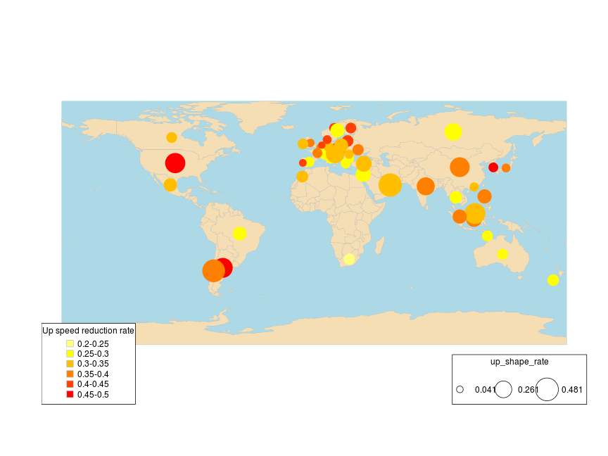

Zoom in Eurasia:

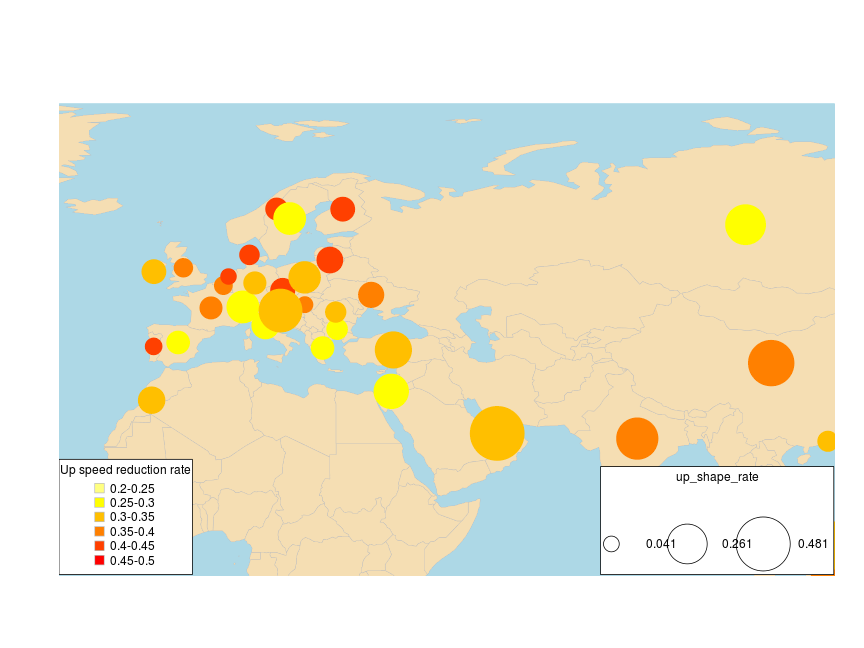

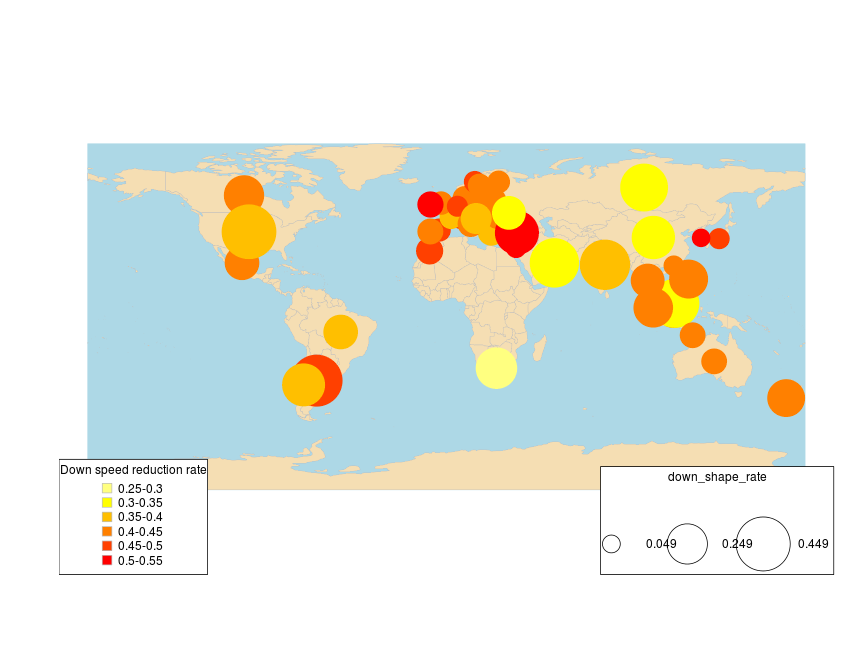

Zoom in Eurasia:

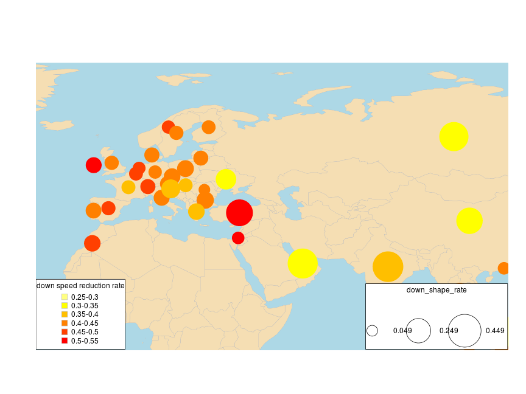

```
##
##  Pearson's Chi-squared test with Yates' continuity correction
##
## data:  table(shaperprobe_ok$upshaper, shaperprobe_ok$downshaper)
## X-squared = 125626, df = 1, p-value < 2.2e-16
```

```
##
##  Fisher's Exact Test for Count Data
##
## data:  table(shaperprobe_ok$upshaper, shaperprobe_ok$downshaper)
## p-value < 2.2e-16
## alternative hypothesis: true odds ratio is not equal to 1
## 95 percent confidence interval:
##  6.714 6.871
## sample estimates:
## odds ratio
##      6.792
```

[output not shown]

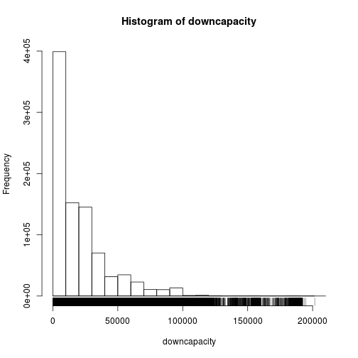

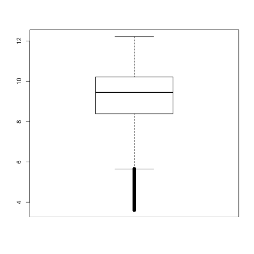

[output not shown]

## Analysis of errors in Shaperprobe

The major problem with Shaperprobe is its poor reliability in some practical cases to detect traffic shaping. Some manual testing in real conditions shows the existance of errors. In fact, the final user approach has many advantages, but also the drawback of having to deal with an uncontroled environnement. Many applications pr users on a single Internet connection can create speed variations which could mislead Shaperprobe.

Our approach is to analyse these errors with IP which have done more than 50 tests. They represents a total of 275 IP adresses. This allows us to consider the real result (with/without traffic shaping) of each IP as the majority result. This is a strong hypothesis which will under-estimate the global error rate (beacause each IP error rate has a maximum of ½). Moreover, it supposes that biggest IP are representative of all Internet connection, which can be not true. But it gives a overview of the situation.

### Up or Down Traffic Shaping

We begin by studing errors in detecting traffic shaping in upload or in download.

The mean of error rates for each IP (false positive and false negative), which have done more than 50 tests, is : 13.049%. This is an estimation of minimum of global error rate which we observe with Shaperprobe.

Its histogramm is represented below.

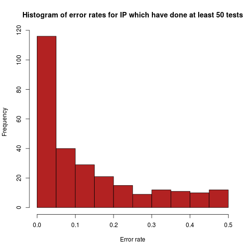

We can also compute a confidence interval for the mean of error rates at 95% : [11.361 ; 14.738]. This is to say that the true value our estimator of the global error rate is in this interval with a risk of 5%.

#### Alternative way to analyse errors

Number of right true estimated by our method : 132. Number of right false estimated : 143

| in % | Estimated | Real Results |
| --- | --- | --- |
| **Empirical results** | *TRUE* | *FALSE* |
| *FALSE* | *False Negative* | *True Negative* |
|  | 3.68 | 56.26 |
| *TRUE* | *True Positive* | *False Positive* |
|  | 31.61 | 8.45 |

Real value = True Positive + False Negative - False Positive

Correction term = False Negative - False Positive = **-4.772**

### Up traffic shaping only

Mean of error rates for each IP (false positve and false negative) 12.637%

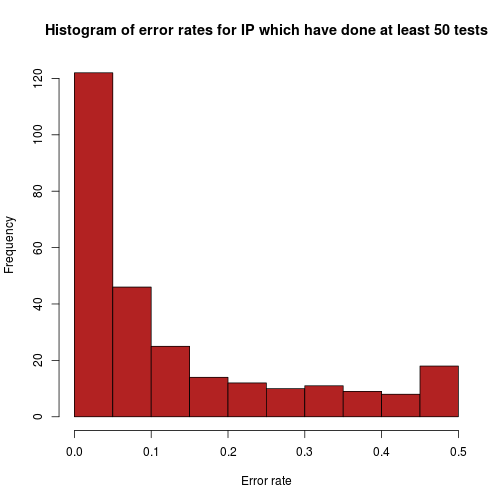

Confidence interval at 95% : [10.904 ; 14.371]

#### Alternative way to analyse errors

Number of right true estimated by our method : 87. Number of right false estimated : 188

| in % | Estimated | Real Results |
| --- | --- | --- |
| **Empirical results** | *TRUE* | *FALSE* |
| *FALSE* | *False Negative* | *True Negative* |
|  | 3.96 | 69.33 |
| *TRUE* | *True Positive* | *False Positive* |
|  | 19.96 | 6.75 |

Real value = True Positive + False Negative - False Positive

Correction term = False Negative - False Positive = **-2.784**

### Down traffic shaping only

Mean of error rates for each IP (false positve and false negative) 13.399%

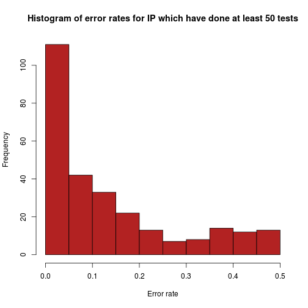

Confidence interval at 95% : [11.704 ; 15.094]

#### Alternative way to analyse errors

Number of right true estimated by our method : 116. Number of right false estimated : 159

| in % | Estimated | Real Results |
| --- | --- | --- |
| **Empirical results** | *TRUE* | *FALSE* |
| *FALSE* | *False Negative* | *True Negative* |
|  | 4.17 | 61.85 |
| *TRUE* | *True Positive* | *False Positive* |
|  | 27.34 | 6.63 |

Real value = True Positive + False Negative - False Positive

Correction term = False Negative - False Positive = **-2.463**

## Relation between days of the week and traffic shaping

Below we have represented two calendars heat map of the rate of traffic shaping detected for each day : one in upload and another one in download. Keep in mind that there were just a few tests at the begin, so we can observe a lot of variations.

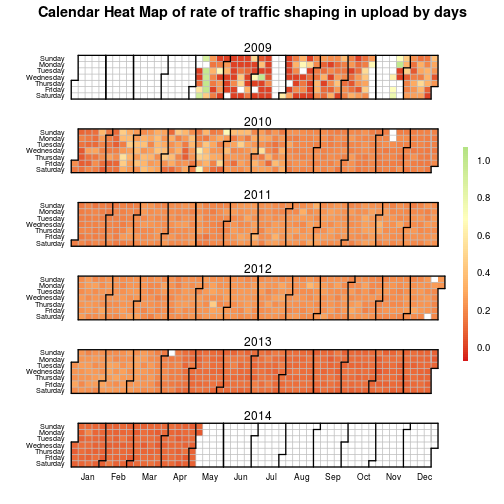

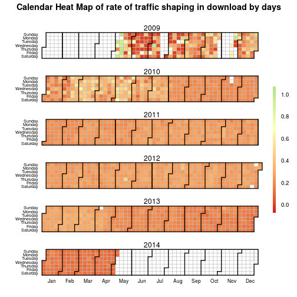

## Relation between local hour and traffic shaping

We could wonder if there is a relation between traffic shaping and the hour of the day, in other words if ISP implement traffic shaping depending on the load of the network (which is related to the local hour). We represent below the bar charts of rates of traffic shaping (in upload or download, in upload only and in download only) depending on the local hour of the day.

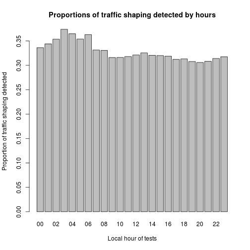

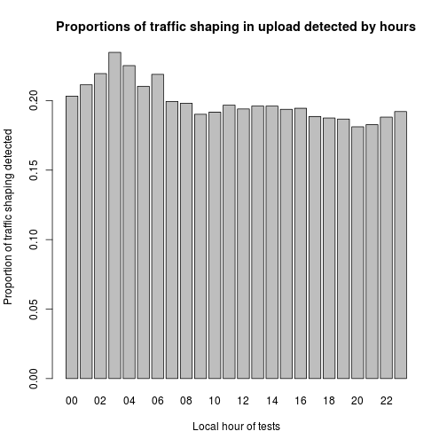

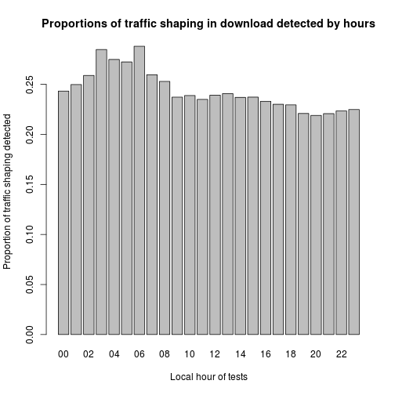

These graphical representations are quite simple, and this question should be analysed in more details.

## Relation between capacity and traffic shaping

Is there a relationship between traffic shaping and capacity of connection ? In other words, could we determine if traffic shaping help to manage networks ? The classical argument in favor of traffic shaping is that it handles network « jam ».

| Mean in Kbps | Traffic shaping detected | Traffic shaping not detected |
| --- | --- | --- |
| Vitesse upload | 4862 | 4556.7 |
| Vitesse download | 2.3326 × 10<sup>4</sup> | 1.8957 × 10<sup>4</sup> |

| Median in Kbps | Traffic shaping détecté | Traffic shaping non-détécté |
| --- | --- | --- |
| Vitesse upload | 3937 | 981.4 |
| Vitesse download | 2.2601 × 10<sup>4</sup> | 9825 |

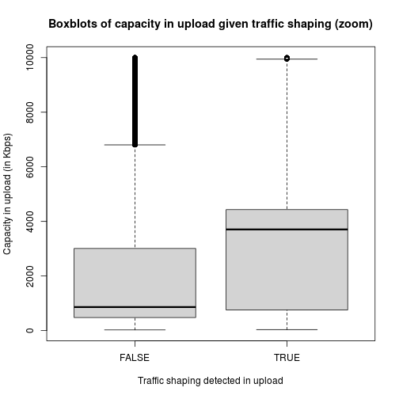

```
##
##  Welch Two Sample t-test
##
## data:  upcapacityWithUpshaper and upcapacityWithoutUpshaper
## t = 15.31, df = 372766, p-value < 2.2e-16
## alternative hypothesis: true difference in means is not equal to 0
## 95 percent confidence interval:
##  266.3 344.5
## sample estimates:
## mean of x mean of y
##      4862      4557
```

```
##
##  F test to compare two variances
##
## data:  upcapacityWithUpshaper and upcapacityWithoutUpshaper
## F = 0.474, num df = 173859, denom df = 720038, p-value < 2.2e-16
## alternative hypothesis: true ratio of variances is not equal to 1
## 95 percent confidence interval:
##  0.4708 0.4771
## sample estimates:
## ratio of variances
##              0.474
```

```
##
##  Two Sample t-test
##
## data:  upcapacityWithUpshaper and upcapacityWithoutUpshaper
## t = 12.27, df = 893897, p-value < 2.2e-16
## alternative hypothesis: true difference in means is not equal to 0
## 95 percent confidence interval:
##  256.6 354.2
## sample estimates:
## mean of x mean of y
##      4862      4557
```

```
##
##  Wilcoxon rank sum test with continuity correction
##
## data:  upcapacityWithUpshaper and upcapacityWithoutUpshaper
## W = 7.541e+10, p-value < 2.2e-16
## alternative hypothesis: true location shift is not equal to 0
```

```
##
##  Two-sample Kolmogorov-Smirnov test
##
## data:  upcapacityWithUpshaper and upcapacityWithoutUpshaper
## D = 0.3228, p-value < 2.2e-16
## alternative hypothesis: two-sided
```

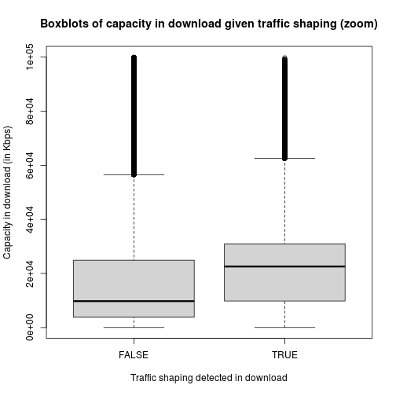

```
##
##  Welch Two Sample t-test
##
## data:  downcapacityWithDownshaper and downcapacityWithoutDownshaper
## t = 92.79, df = 453438, p-value < 2.2e-16
## alternative hypothesis: true difference in means is not equal to 0
## 95 percent confidence interval:
##  4277 4462
## sample estimates:
## mean of x mean of y
##     23326     18957
```

```
##
##  F test to compare two variances
##
## data:  downcapacityWithDownshaper and downcapacityWithoutDownshaper
## F = 0.5854, num df = 210983, denom df = 682913, p-value < 2.2e-16
## alternative hypothesis: true ratio of variances is not equal to 1
## 95 percent confidence interval:
##  0.5818 0.5889
## sample estimates:
## ratio of variances
##             0.5854
```

```
##
##  Two Sample t-test
##
## data:  downcapacityWithDownshaper and downcapacityWithoutDownshaper
## t = 80.75, df = 893896, p-value < 2.2e-16
## alternative hypothesis: true difference in means is not equal to 0
## 95 percent confidence interval:
##  4263 4475
## sample estimates:
## mean of x mean of y
##     23326     18957
```

```
##
##  Wilcoxon rank sum test with continuity correction
##
## data:  downcapacityWithDownshaper and downcapacityWithoutDownshaper
## W = 8.967e+10, p-value < 2.2e-16
## alternative hypothesis: true location shift is not equal to 0
```

```
##
##  Two-sample Kolmogorov-Smirnov test
##
## data:  downcapacityWithDownshaper and downcapacityWithoutDownshaper
## D = 0.3234, p-value < 2.2e-16
## alternative hypothesis: two-sided
```

La différence de capacité de connexion entre présence/absence de traffic shaping est significative

Cependant, ne pas en conclure que le traffic shaping conduit à de meilleurs débits : il y a simultanéité

- le TS participe à fluidifier le réseau
- le TS est mis en place sur de grosses connexions

## Capacité de connexion

```
## [1] 0.5632
```

```
##
##  Pearson's product-moment correlation
##
## data:  shaperprobe_ok$upcapacity and shaperprobe_ok$downcapacity
## t = 644.4, df = 893897, p-value < 2.2e-16
## alternative hypothesis: true correlation is not equal to 0
## 95 percent confidence interval:
##  0.5618 0.5646
## sample estimates:
##    cor
## 0.5632
```

Analyser vitesse connexion avec capacity ou medianrate ??

```
##     0%    10%    20%    30%    40%    50%    60%    70%    80%    90%
##     36   1238   2924   5136   8339  12700  18951  24461  31431  51357
##   100%
## 201616
```

```
## [1] 19988
```

```
## [1] 12700
```

```
## [1] 14281
```

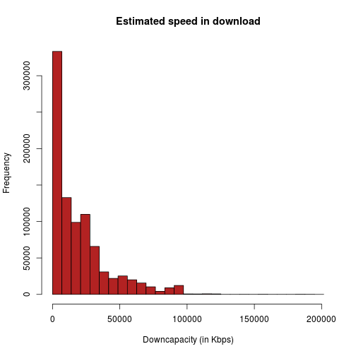

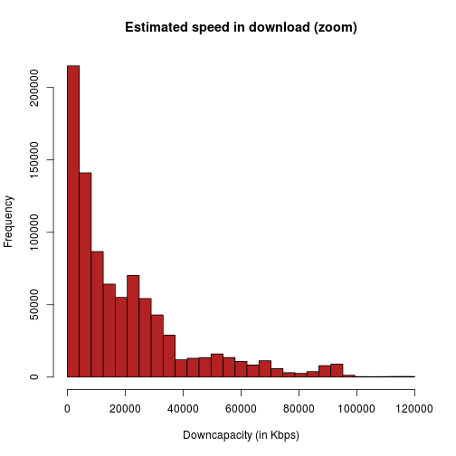

```
##        0%       10%       20%       30%       40%       50%       60%
##     24.67    318.51    462.04    672.95    859.54   1273.13   3051.23
##       70%       80%       90%      100%
##   4299.09   5860.75  10786.82 192089.57
```

```
## [1] 4616
```

```
## [1] 1273
```

```
## [1] 2224
```

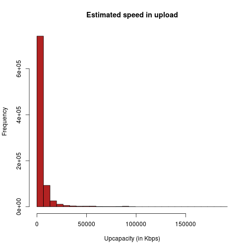

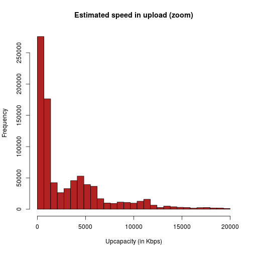

Représentation carto mondiale des vitesses de connexion

Réduire à une plus petite période ? Faire depuis 2009 n'a pas de sens ou visualisation dans le temps

TODO : évolution au cours du temps. On voit que pour les 1ers tests quelques vitesses très élevées : ils étaient à coté des serveurs

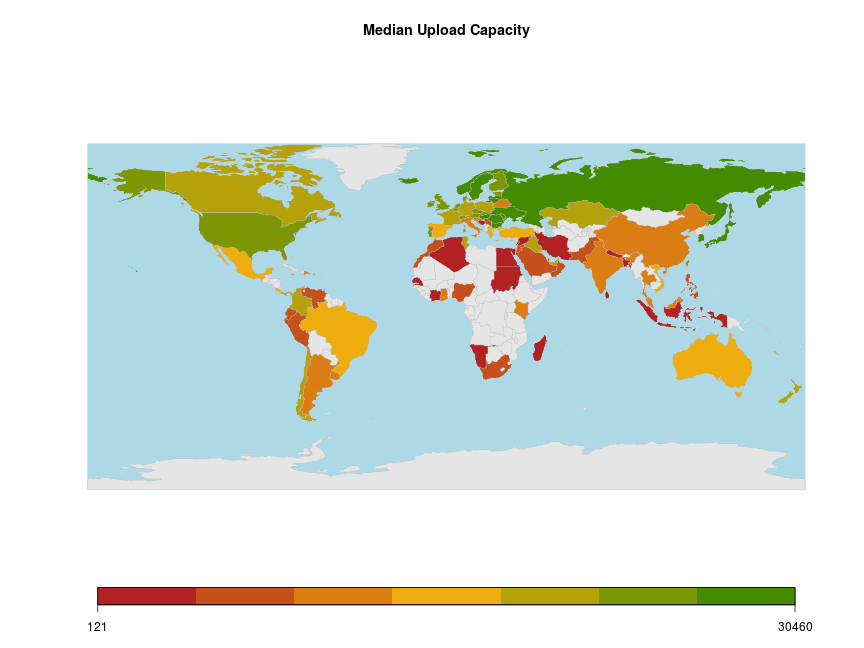

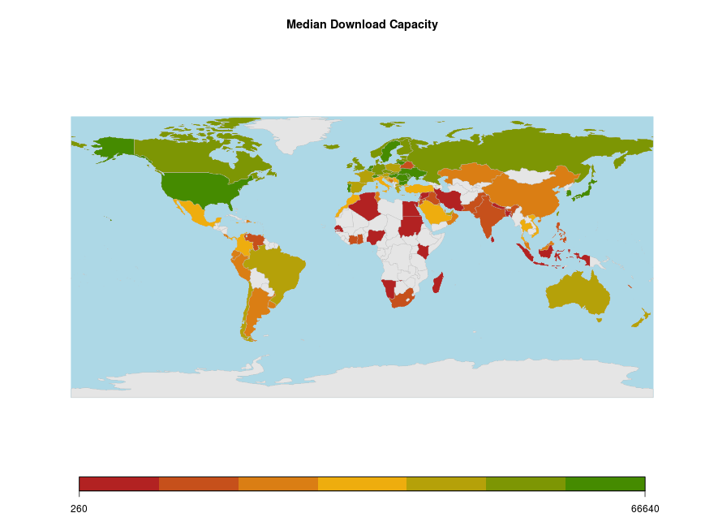

This page was automatically generated the 29/09/2014 at 15:59:43. The content generated is licensed under the [Creative Commons Attribution 4.0 International License](http://creativecommons.org/licenses/by/4.0/). The software behind is under [GNU General Public License](http://www.gnu.org/licenses/gpl.txt) and the sources are on [github](https://github.com/Framartin/MeasureNetNeutrality).